# The Monthly Amount of Criminal Incidents in Chicago

# 7.Future analysis

We noticed evidence of 1 year cycle of the amount of the criminal incidents. I think it is worth investigating the reason of the open down parabola pattern.

**Unemployment Rate and Crime**

A brief look into the relationship between crime numbers and unemployment rate is reasonable. It is make sense that the change of the unemployment rate will influence the crime numbers. The unemployment will make people’s living hard so that they may commit crime to make a living.

The unemployment rate data shown below is retrieved from https://fred.stlouisfed.org/series/CHIC917URN.

[figure not shown]

We can see that the pattern and trend of Unemploymen rate and the crime numbers are very different. Without further explore, it hard to conclude that the Unemploymen rate and the crime numbers are correlated in Chicago.

**Climate and Crime**

Exploring the relationship between climate and unemployment rate is also reasonable. Since winter of Chicago is harsh, it seems like natural that the crime number will decrease when the temperature becomes lower. When the winter comes, the temperature will be low and always snow a lot. Therefore, people tends to stay in one place rather than linger around outside.

The climate data shown below is retrieved from https://www.climatestations.com/chicago/. We will take a look at the climate data of 4 years: 2001, 2005, 2009, 2017 for generallity.

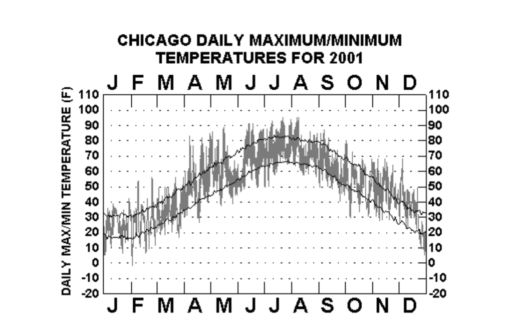

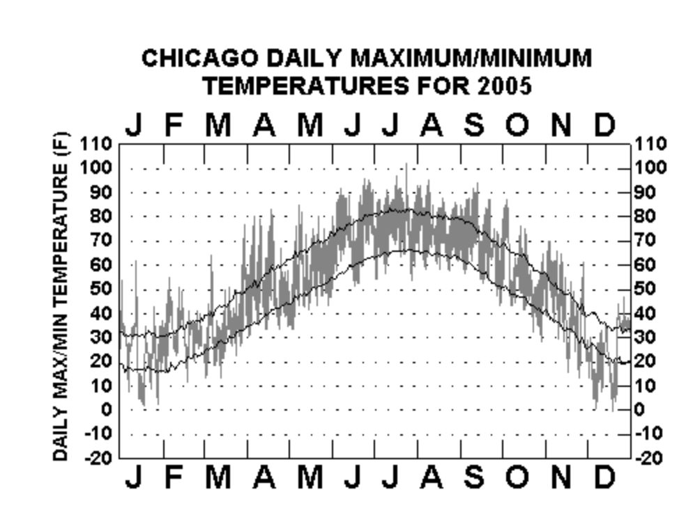

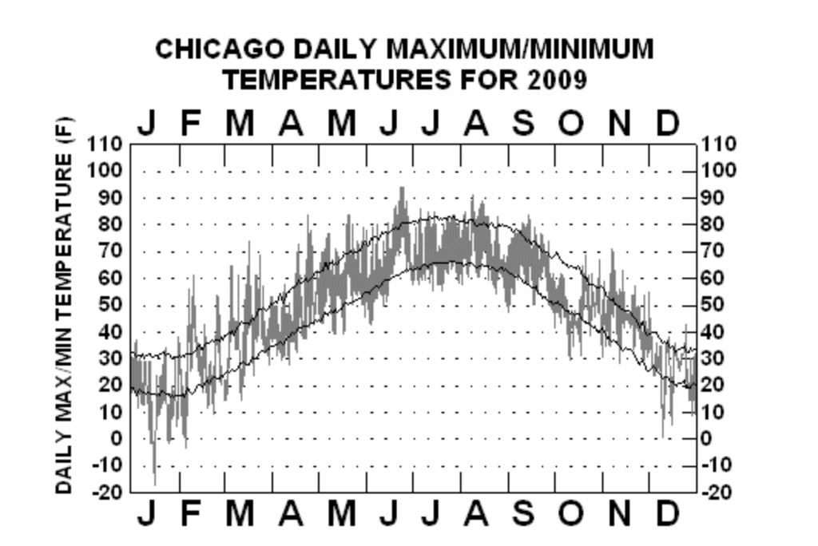

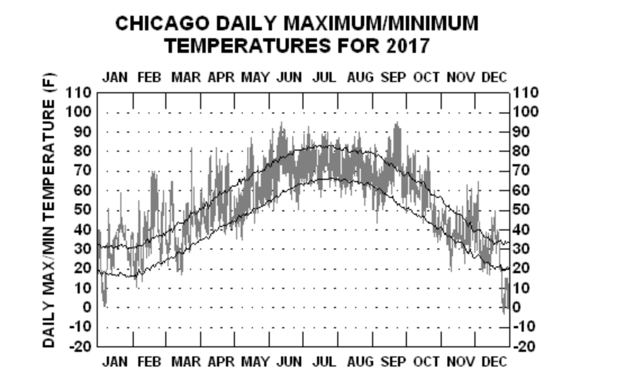

We can see that the pattern of the Chicago climate within one year is similar to the crime numbers. Both of them are open down parabola and reach the peak around the middle of year (Jun, Jul Aug). Here, since without further analysis, it is just possible that the climate is related with the crime activities. When the temperature is high, the crime activities will be more active. In the future, this will be worth to explore more.

# 8.References

Ionides, E. (n.d.). Stats 531 (2018, winter). ‘Analysis of Time Series’. Retrieved from http://ionides.github.io/531w18/

Rafael Mangual (2017, summer). Sub-Chicago and America’s Real Crime Rate. Retrieved from

https://www.city-journal.org/html/sub-chicago-and-americas-real-crime-rate-15341.html.

Chicago Data Portal (2018, March). Crimes - 2001 to present. Retrieved from https://data.cityofchicago.org/Public-Safety/Crimes-2001-to-present/ijzp-q8t2

FRED Economic Data. Unemployment Rate in Chicago-Naperville-Elgin, IL-IN-WI (MSA). Retrieved from https://fred.stlouisfed.org/series/CHIC917URN

ClimateStations. Graphical Climatology of Chicago (1871-Present). Retrieved from https://www.climatestations.com/chicago/